### Question 1

Support Vector Machines (SVM) classifier belongs to a class of

Linear models  
Tree-based models  
Nearest Neighbours based  
Neural Networks

### Question 2

What is the difference between RandomForest and ExtraTrees models from sklearn?

ExtraTrees classifier always uses only a fraction of objects when looking for a split (in contrast to Random Forest, which uses all object)  
ExtraTrees classifier always tests random splits over fraction of features (in contrast to RandomForest, which tests all possible splits over fraction of features)  
ExtraTrees classifier always uses only a fraction of features when looking for a split (in contrast to Random Forest, which uses all features)

### Question 3

What model was most probably used to produce such decision surface? Color (from white to purple) shows predicted probability for a point to be of class "red".

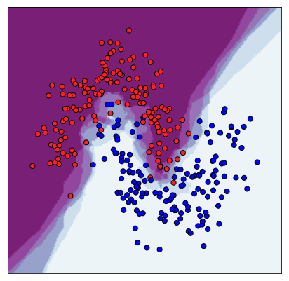

Decision Tree  
kNN  
Linear model  
Random Forest

### Question 4

What model was most probably used to produce such decision surface? Color (from white to purple) shows predicted probability for a point to be of class "red".

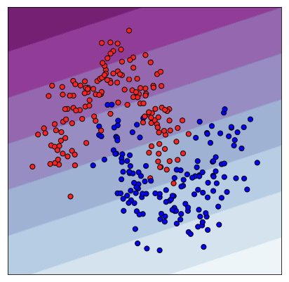

Random Forest  
Decision Tree  
Linear model  
k-NN